# Intro_to_statitical_learning_with_R_c2_exercises

# Conceptual

## Question 1

Indicate the general expected performance of a flexible statistical learning method whether to be better or worse than an inflexible method.

1. The sample size **n** is extremely large, and the number of predictors **p** is small.

A flexible statistical learning method would perform better.They do not assume a shape of the functional relationship between response and predictors.

2. The number of predictors p is extremely large, and the number of observations n is small.

An inflexible method would perform better because flexible methods require a large number of observations.

3. The relationship between the predictors and response is highly non-linear.

A flexible method would perform better - inflexible methods are restricted by the functional form of f to capture the relationship between predictors and response. A flexible method not restricted by form and tries to model the form based on the data points.

## Question 2

Explain whether each scenario is a classification or regression problem, and indicate whether we are most interested in inference or prediction. Finally, provide n and p

1. **We collect a set of data on the top 500 firms in the US. For each firm we record profit, number of employees, industry and the CEO salary. We are interested in understanding which factors affect CEO salary.**

This is a regression problem as we are trying to infer the relationship with a continuous quantitative response value. *n* is 500. *p* is 3

2. **We are considering launching a new product and wish to know whether it will be a success or a failure. We collect data on 20 similar products that were previously launched. For each product we have recorded whether it was a success or failure, price charged for the product, marketing budget, competition price,and ten other variables.**

This is a classification problem where the response is a binary qualitative response - success or failure. *n* is 20. *p* is 13.

3. **We are interested in predicting the % change in the USD/Euro exchange rate in relation to the weekly changes in the world stock markets. Hence we collect weekly data for all of 2012. For each week we record the % change in the USD/Euro, the % change in the US market, the % change in the British market,and the % change in the German market.**

This is a regression problem - quantitative continuous response variable. *n* is 52. p is *3*.

## Question 3

```r
library(ISLR)
library(ggplot2)
library(dplyr)
#library(plotly)
```

Read in the `College` data set with the `read.csv()` function.

```r
# read in the College data set
college <- read.csv("../data/College.csv")
```

```r
# give each row name corresponding to the appropriate college name
rownames(college) <- college[,1]
```

```r
# remove the first column where college names stored
college <- college[,-1]
```

```r
# use summary function to produce numerical summary of the variables in the data set
summary(college)
```

```
   Private               Apps           Accept          Enroll       Top10perc       Top25perc
 Length:777         Min.   :   81   Min.   :   72   Min.   :  35   Min.   : 1.00   Min.   :  9.0
 Class :character   1st Qu.:  776   1st Qu.:  604   1st Qu.: 242   1st Qu.:15.00   1st Qu.: 41.0
 Mode  :character   Median : 1558   Median : 1110   Median : 434   Median :23.00   Median : 54.0
                    Mean   : 3002   Mean   : 2019   Mean   : 780   Mean   :27.56   Mean   : 55.8
                    3rd Qu.: 3624   3rd Qu.: 2424   3rd Qu.: 902   3rd Qu.:35.00   3rd Qu.: 69.0
                    Max.   :48094   Max.   :26330   Max.   :6392   Max.   :96.00   Max.   :100.0
  F.Undergrad     P.Undergrad         Outstate       Room.Board       Books           Personal
 Min.   :  139   Min.   :    1.0   Min.   : 2340   Min.   :1780   Min.   :  96.0   Min.   : 250
 1st Qu.:  992   1st Qu.:   95.0   1st Qu.: 7320   1st Qu.:3597   1st Qu.: 470.0   1st Qu.: 850
 Median : 1707   Median :  353.0   Median : 9990   Median :4200   Median : 500.0   Median :1200
 Mean   : 3700   Mean   :  855.3   Mean   :10441   Mean   :4358   Mean   : 549.4   Mean   :1341
 3rd Qu.: 4005   3rd Qu.:  967.0   3rd Qu.:12925   3rd Qu.:5050   3rd Qu.: 600.0   3rd Qu.:1700
 Max.   :31643   Max.   :21836.0   Max.   :21700   Max.   :8124   Max.   :2340.0   Max.   :6800
      PhD            Terminal       S.F.Ratio      perc.alumni        Expend        Grad.Rate
 Min.   :  8.00   Min.   : 24.0   Min.   : 2.50   Min.   : 0.00   Min.   : 3186   Min.   : 10.00
 1st Qu.: 62.00   1st Qu.: 71.0   1st Qu.:11.50   1st Qu.:13.00   1st Qu.: 6751   1st Qu.: 53.00
 Median : 75.00   Median : 82.0   Median :13.60   Median :21.00   Median : 8377   Median : 65.00
 Mean   : 72.66   Mean   : 79.7   Mean   :14.09   Mean   :22.74   Mean   : 9660   Mean   : 65.46
 3rd Qu.: 85.00   3rd Qu.: 92.0   3rd Qu.:16.50   3rd Qu.:31.00   3rd Qu.:10830   3rd Qu.: 78.00
 Max.   :103.00   Max.   :100.0   Max.   :39.80   Max.   :64.00   Max.   :56233   Max.   :118.00
```

- Use the `pairs()` function to produce a scatter plot matrix of the first ten columns or variables of the data.

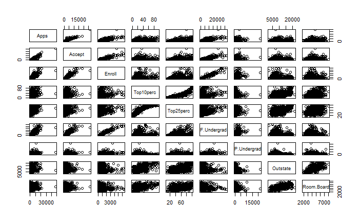

```r
# create a scatter plot matrix with the first 10 predictors in college datasec
pairs(college[, 2:10])
```

- Use the `plot()` function to produce side by side box plots of `Outstate` vs `Private`.

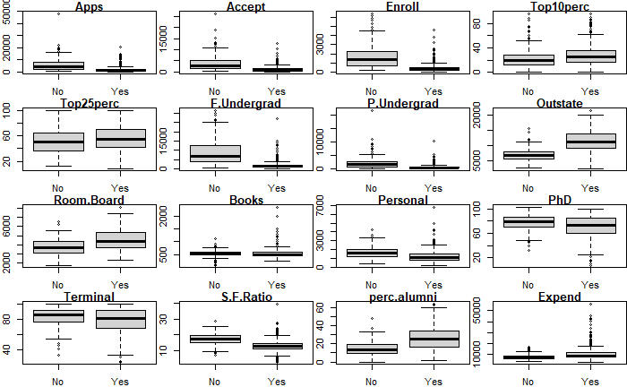

```r
# create multiple plots - 4 rows and 4 columns with margin - top right bottom left
par(mfrow=c(4,4), mar=c(2,2,1,0))

for (i in 2:17)
  boxplot(college[, i] ~ college[, 1], xlab="", main=colnames(college)[i])
```

- Create a new qualitative variable - `Elite`, by *binning* the top10perv variable.

```r
# create replicated vector of No with length of college
Elite <- rep("No", nrow(college))
# change elite value to yes if Top10Perc above 50
Elite[college$Top10perc > 50] <- "Yes"
# change Elite to a set of distinct qualitative values - factor
Elite <- as.factor(Elite)
# add Elite to College as a categorical variable
college <- data.frame(college, Elite)
summary(college$Elite)
```

```
 No Yes
699  78
```

Based on summary of `Elite` column, there are **78** elite universities in the `College` data set.

Use the ’plot()`function to create side-by-side boxplots of`Outstate`versus`Elite`

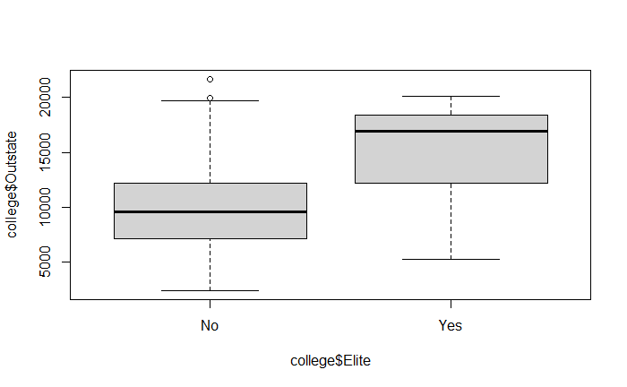

```r
# create multiple plots - 4 rows and 4 columns with margin - top right bottom left

plot(college$Outstate~ college$Elite)
```

```r
par(mfrow=c(2,2))
hist(college$Apps, breaks = 5)
hist(college$Apps, breaks = 10)
```

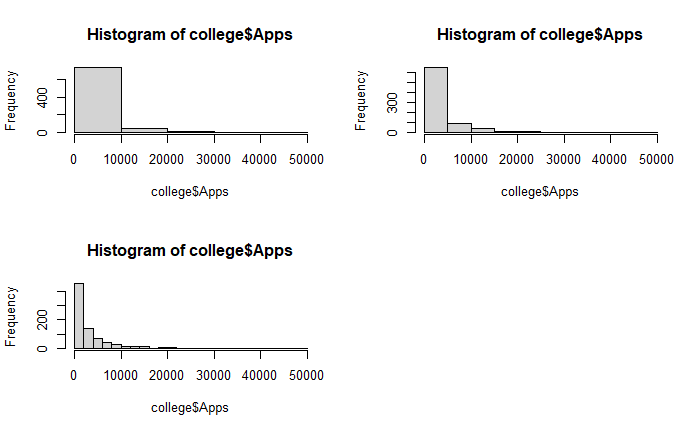

```r
hist(college$Apps, breaks = 20)
hist(college$Apps, breaks = 40)
```

```r
par(mfrow=c(2,2))
hist(college$PhD, breaks = 5)
hist(college$PhD, breaks = 10)
```

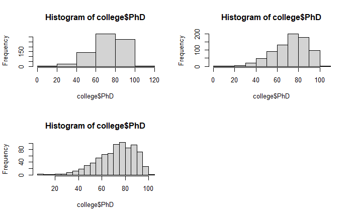

```r
hist(college$PhD, breaks = 20)
hist(college$PhD, breaks = 40)
```